# Setup

```r
library(dplyr)
```

```r
library(ggplot2)
library(tidybayes)
library(rstan)
library(devtools)
library(StanHeaders)
library(readxl)
library(data.table)
library(sma)
library(tidyr)
rstan_options(auto_write = TRUE)
options(mc.cores = parallel::detectCores())
```

# ARCS AREA ANGLES STUDY

## Import Data

This is data that is imported from the Kosara et. al study

Link to study: https://kosara.net/papers/2016/Skau-EuroVis-2016.pdf

Link to data: https://github.com/eagereyes/pie-summaries/blob/master/data/arcs-angles-areas-merged.csv

Hereafter, this study is referred to as the AAA study.

```r
aaa_study <- read_excel("~/Desktop/Research Work/AAA/Arcs Angles Areas Results Data.xlsx" , sheet = "flipped_data")

#this dataset contains data corresponding to all six chart types explored in the paper. However, we are only interested in the Baseline Pie chart.

aaa_study_pie <- subset(aaa_study, chart_type == 'Pie Chart')

## Changed column name of AAA data from subject ID to participant ID to match with value name in the models
colnames(aaa_study_pie)[1] <- "participant_ID"
```

## PIE CHART

### Flipping Results

The AAA study flipped answers for each participant if more than half of the answers for this participant were closer to the opposite segment. However, flipping on participant level might not be accurate since some chart types, such as the angle charts were more ambiguous than others.

To counter this, we flip answers on an observation level. For each observation we flip the answer if the answer is closer to the opposite segment and distance from the correct answer is greater than 8. The value 8 is chosen since most of the data points are within this range (see graph for details).

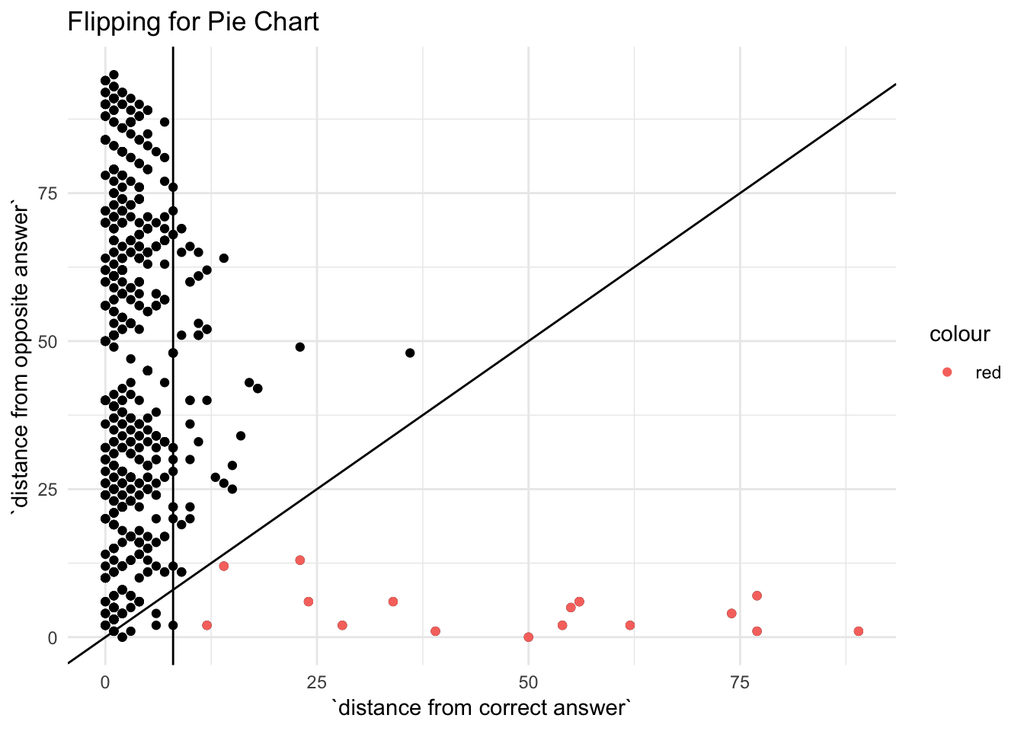

```r
ggplot(aaa_study_pie, aes(x = `distance from correct answer`, y = `distance from opposite answer`)) +
  geom_point() +
  geom_vline(xintercept = 8) +
  geom_abline(intercept = 0, slope = 1) +
  geom_point(aes(color = "red"), data = subset(aaa_study_pie, (`distance from correct answer` > 8) & (`distance from opposite answer` < `distance from correct answer`))) +
  ggtitle('Flipping for Pie Chart')+
    theme_minimal()
```

### Single Cycle Model

Let us try fitting our basic single cycle models to our cleaned data. This model is defined in Holland’s et al and explains the pattern of biases seen in estimation tasks.

#### 1-Cycle

The 1-Cycle model describes a pie chart which has one segment i.e it has reference marks on 0%.

```r
aaa_pie_data = list(n = length(aaa_study_pie$participant_ID), correct_ans = aaa_study_pie$correct_ans/100, response = aaa_study_pie$flipped_ans/100, segments=1)

fit11_aaa_pie <- stan(file = 'models/single_cycle_model.stan', data = aaa_pie_data, iter = 1000, chains = 1, verbose=TRUE)
```

```
##
## TRANSLATING MODEL 'single_cycle_model' FROM Stan CODE TO C++ CODE NOW.
## successful in parsing the Stan model 'single_cycle_model'.
##
## CHECKING DATA AND PREPROCESSING FOR MODEL 'single_cycle_model' NOW.
##
## COMPILING MODEL 'single_cycle_model' NOW.
##
## STARTING SAMPLER FOR MODEL 'single_cycle_model' NOW.
##
```

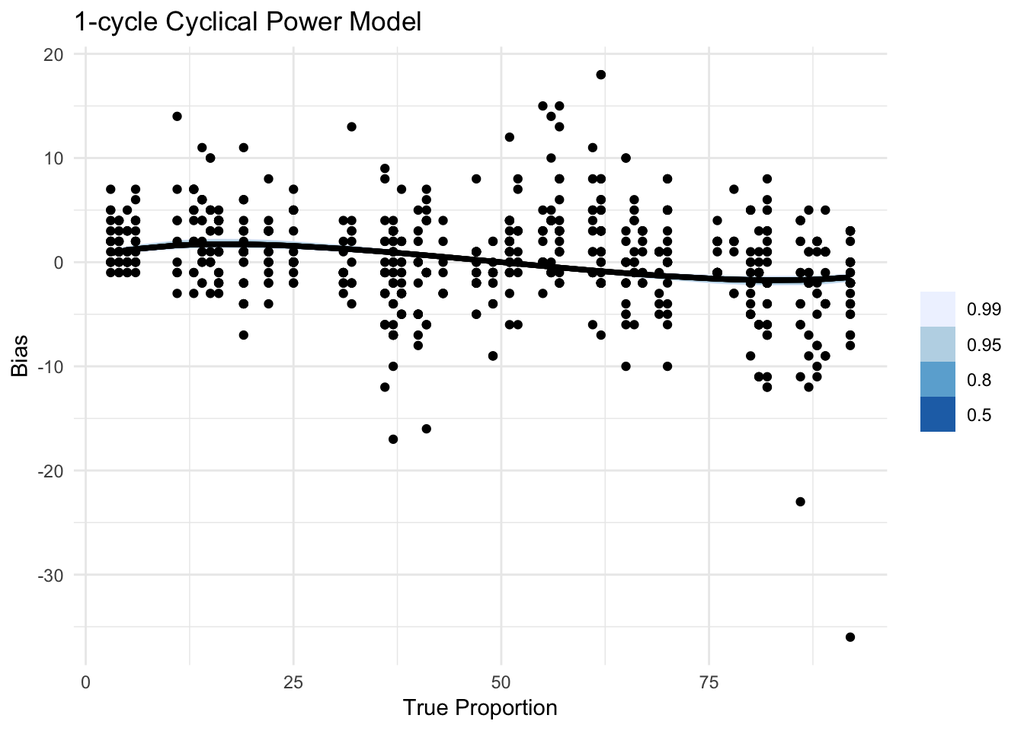

```r
fit11_aaa_pie_data <- spread_draws(fit11_aaa_pie, b)

unique_correct_ans_aaa <- unique(aaa_study_pie$correct_ans)

fit11_aaa_pie_data <- merge(fit11_aaa_pie_data, unique_correct_ans_aaa, all=TRUE)

segments <- c(1);
#update this with segments used in the model

fit11_aaa_pie_data <- fit11_aaa_pie_data%>%
  mutate(
    correct_ans = y/100,
    riminus_value = floor((correct_ans)*segments[1])*(1/segments[1]),
    ri_value = riminus_value + 1/segments[1],
    p = (((correct_ans - riminus_value)^b)/((correct_ans - riminus_value)^b+(ri_value - correct_ans)^b)*(1/segments[1]) + (riminus_value))*100,
    )

fit11_aaa_pie_data %>%
  ggplot(aes(x = y)) +
  stat_lineribbon(aes(y = (p-y)), .width = c(.99, .95, .8, .5)) +
  geom_point(aes(y = (flipped_ans - correct_ans), x = correct_ans ), data = aaa_study_pie) +
  scale_fill_brewer() +
  ggtitle("1-cycle Cyclical Power Model")+
  labs(x = "True Proportion", y="Bias") +
  theme_minimal()
```

#### 2-Cycles

The 2-Cycle model describes a pie chart which has two segments i.e it has reference marks on 0%, 50%, 100%.

```r
aaa_pie_data = list(n = length(aaa_study_pie$participant_ID), correct_ans = aaa_study_pie$correct_ans/100, response = aaa_study_pie$flipped_ans/100, segments=2)

fit12_aaa_pie <- stan(file = 'models/single_cycle_model.stan', data = aaa_pie_data, iter = 1000, chains = 1, verbose=TRUE)
```

```
##
## TRANSLATING MODEL 'single_cycle_model' FROM Stan CODE TO C++ CODE NOW.
## successful in parsing the Stan model 'single_cycle_model'.
##
## CHECKING DATA AND PREPROCESSING FOR MODEL 'single_cycle_model' NOW.
##
## COMPILING MODEL 'single_cycle_model' NOW.
##
## STARTING SAMPLER FOR MODEL 'single_cycle_model' NOW.
##
```

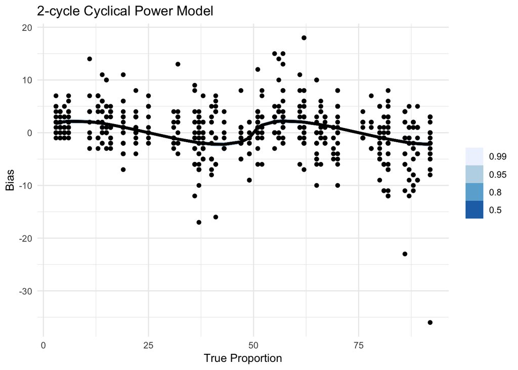

```r
#model <- stan_model(file = 'models/single_cycle_model.stan')

fit12_aaa_pie_data <- spread_draws(fit12_aaa_pie, b)

unique_correct_ans_aaa <- unique(aaa_study_pie$correct_ans)

fit12_aaa_pie_data <- merge(fit12_aaa_pie_data, unique_correct_ans_aaa, all=TRUE)

segments <- c(2);
#update this with segments used in the model

fit12_aaa_pie_data <- fit12_aaa_pie_data%>%
  mutate(
    correct_ans = y/100,
    riminus_value = floor((correct_ans)*segments[1])*(1/segments[1]),
    ri_value = riminus_value + 1/segments[1],
    p = (((correct_ans - riminus_value)^b)/((correct_ans - riminus_value)^b+(ri_value - correct_ans)^b)*(1/segments[1]) + (riminus_value))*100,
    )

fit12_aaa_pie_data %>%
  ggplot(aes(x = y)) +
  stat_lineribbon(aes(y = (p-y)), .width = c(.99, .95, .8, .5)) +
  geom_point(aes(y = (flipped_ans - correct_ans), x = correct_ans ), data = aaa_study_pie) +
  scale_fill_brewer() +
  ggtitle("2-cycle Cyclical Power Model")+
  labs(x = "True Proportion", y="Bias") +
  theme_minimal()
```

#### 4-Cycles

The 4-Cycle model describes a pie chart which has four segments i.e it has reference marks on 0%, 25%, 50%, 75%, 100%.

```r
aaa_pie_data = list(n = length(aaa_study_pie$participant_ID), correct_ans = aaa_study_pie$correct_ans/100, response = aaa_study_pie$flipped_ans/100, segments=4)

fit14_aaa_pie <- stan(file = 'models/single_cycle_model.stan', data = aaa_pie_data, iter = 1000, chains = 1, verbose=TRUE)
```

```
##
## TRANSLATING MODEL 'single_cycle_model' FROM Stan CODE TO C++ CODE NOW.
## successful in parsing the Stan model 'single_cycle_model'.
##
## CHECKING DATA AND PREPROCESSING FOR MODEL 'single_cycle_model' NOW.
##
## COMPILING MODEL 'single_cycle_model' NOW.
##
## STARTING SAMPLER FOR MODEL 'single_cycle_model' NOW.
##
```

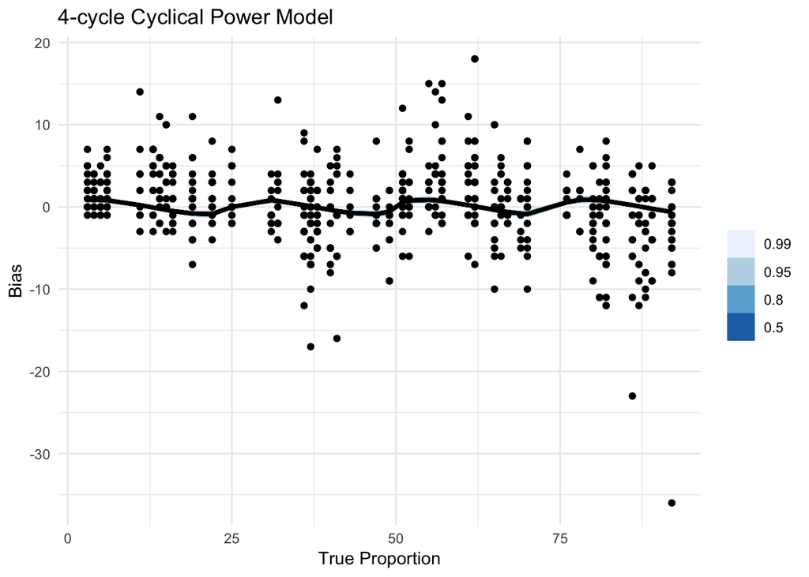

```r
#model <- stan_model(file = 'models/single_cycle_model.stan')

fit14_aaa_pie_data <- spread_draws(fit14_aaa_pie, b)

unique_correct_ans_aaa <- unique(aaa_study_pie$correct_ans)

fit14_aaa_pie_data <- merge(fit14_aaa_pie_data, unique_correct_ans_aaa, all=TRUE)

segments <- c(4);
#update this with segments used in the model

fit14_aaa_pie_data <- fit14_aaa_pie_data%>%
  mutate(
    correct_ans = y/100,
    riminus_value = floor((correct_ans)*segments[1])*(1/segments[1]),
    ri_value = riminus_value + 1/segments[1],
    p = (((correct_ans - riminus_value)^b)/((correct_ans - riminus_value)^b+(ri_value - correct_ans)^b)*(1/segments[1]) + (riminus_value))*100,
    )

fit14_aaa_pie_data %>%
  ggplot(aes(x = y)) +
  stat_lineribbon(aes(y = (p-y)), .width = c(.99, .95, .8, .5)) +
  geom_point(aes(y = (flipped_ans - correct_ans), x = correct_ans ), data = aaa_study_pie) +
  scale_fill_brewer() +
  ggtitle("4-cycle Cyclical Power Model")+
  labs(x = "True Proportion", y="Bias") +
  theme_minimal()
```

### Pooled Weights and Pooled Power Model (Weighted Cycles Model)

The Pooled Weights and Pooled Power Model, also referred to as the Weighted Cycles Model is a mixture model of the earlier single cycles model (1 Cycle, 2 Cycle and 4 Cycle).

```r
aaa_pie_data = list(n = length(aaa_study_pie$participant_ID), number_segments = 3, correct_ans = aaa_study_pie$correct_ans/100, response = aaa_study_pie$flipped_ans/100, segments = c(1,2,4))

fit2_aaa_pie <- stan(file = 'models/weighted_cycles_model.stan', data = aaa_pie_data, iter = 1000, chains = 1, verbose=TRUE)
```

```
##
## TRANSLATING MODEL 'weighted_cycles_model' FROM Stan CODE TO C++ CODE NOW.
## successful in parsing the Stan model 'weighted_cycles_model'.
```

```
## recompiling to avoid crashing R session
```

[output not shown]

[output cut: 1001 more lines]

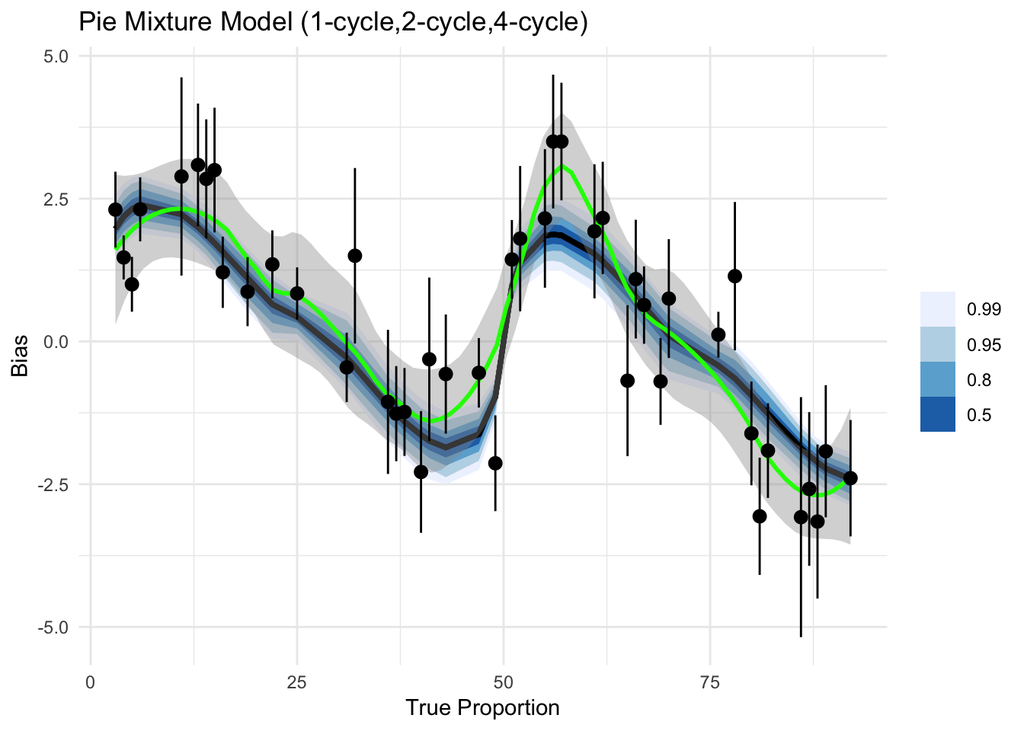

```r
saveRDS(fit2_aaa_pie, "fit_aaa_weighted_cycles.rds")

#fit2_pie <- readRDS("fit_aaa_weighted_cycles.rds")

#building the new DB
b_and_p <- as.matrix(fit2_aaa_pie, pars = c("prob_segment", "b" ))
fit_data_m_aaa <- as.data.frame(b_and_p)

unique_correct_ans <- as.data.frame(unique(aaa_study_pie$correct_ans))

fit_data_m_aaa <- cbind(fit_data_m_aaa, correct_ans = rep(unique_correct_ans$`unique(aaa_study_pie$correct_ans)`, each = nrow(fit_data_m_aaa)))

    b = fit_data_m_aaa$b
    prob_segment1 = fit_data_m_aaa$`prob_segment[1]`
    prob_segment2 = fit_data_m_aaa$`prob_segment[2]`
    prob_segment3 = fit_data_m_aaa$`prob_segment[3]`
    segment1 = 1
    segment2 = 2
    segment3 = 4
    correct_ans = fit_data_m_aaa$correct_ans/100

    riminus_value1 = floor(correct_ans*segment1)*(1/segment1);
    ri_value1 = riminus_value1 + 1/segment1;
    p1 = ((correct_ans - riminus_value1)^b)/((correct_ans - riminus_value1)^b+(ri_value1 - correct_ans)^b)*(1/segment1) + (riminus_value1);

    riminus_value2 = floor(correct_ans*segment2)*(1/segment2);
    ri_value2 = riminus_value2 + 1/segment2;
    p2 = ((correct_ans - riminus_value2)^b)/((correct_ans - riminus_value2)^b+(ri_value2 - correct_ans)^b)*(1/segment2) + (riminus_value2);

    riminus_value3 = floor(correct_ans*segment3)*(1/segment3);
    ri_value3 = riminus_value3 + 1/segment3;
    p3 = ((correct_ans - riminus_value3)^b)/((correct_ans - riminus_value3)^b+(ri_value3 - correct_ans)^b)*(1/segment3) + (riminus_value3);

    fit_data_m_aaa$p = (prob_segment1*p1 + prob_segment2*p2 + prob_segment3*p3)*100;

  fit_data_m_aaa %>%
  ggplot(aes(x = correct_ans)) +
  stat_lineribbon(aes(y = (p-correct_ans)), .width = c(.99, .95, .8, .5)) +
 # geom_point(aes(y = (flipped_ans - correct_ans), x = correct_ans ), data = flipped_pie_angle) +
  stat_smooth(data=aaa_study_pie, aes(x =correct_ans, y =(flipped_ans-correct_ans) ) , color = "green", span = .3) +
  stat_summary(fun.data = "mean_se", geom="pointrange", data = aaa_study_pie, aes(x =correct_ans, y =(flipped_ans-correct_ans))) +
  scale_fill_brewer() +
  ggtitle("Pie Mixture Model (1-cycle,2-cycle,4-cycle)") +
  labs(x = "True Proportion", y="Bias") +
  theme_minimal()
```

```r
    mean(fit_data_m_aaa$`prob_segment[1]`)
```

```
## [1] 0.09874875
```

```r
    mean(fit_data_m_aaa$`prob_segment[2]`)
```

```
## [1] 0.7092433
```

```r
    mean(fit_data_m_aaa$`prob_segment[3]`)
```

```
## [1] 0.192008
```

#### Pooled Weights and Pooled Power Model for 1-99 values

Let us see how this model works for a larger number of input values.

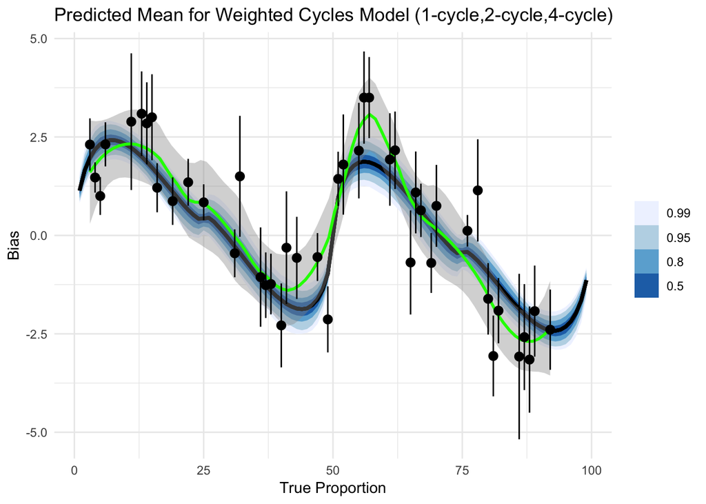

```r
fit_data_aaa <- spread_draws(fit2_aaa_pie, b, prob_segment[segment])

all_numbers <- (seq(1, 99, 1))

fit_data_aaa_merge <- merge(fit_data_aaa, all_numbers, all=TRUE)
# y stands for the correct answer

temp <- merge(fit_data_aaa, all_numbers, all=TRUE)

segments <- c(1,2,4);
#update this with segments used in the model

final_data_aaa_w <- fit_data_aaa_merge%>%
  mutate(
    correct_ans = y/100,
    riminus_value = floor((correct_ans)*segments[segment])*(1/segments[segment]),
    ri_value = riminus_value + 1/segments[segment],
    p = ((correct_ans - riminus_value)^b)/((correct_ans - riminus_value)^b+(ri_value - correct_ans)^b)*(1/segments[segment]) + (riminus_value),
    weighted_p = p*prob_segment*100
    ) %>%
      group_by(.chain, .iteration, b, y) %>%
        summarise(final_p = sum(weighted_p))

final_data_aaa_w %>%
  ggplot(aes(x = y)) +
  stat_lineribbon(aes(y = (final_p-y)), .width = c(.99, .95, .8, .5)) +
 # geom_point(aes(y = (flipped_ans - correct_ans), x = correct_ans ), data = flipped_pie_angle) +
  stat_smooth(data=aaa_study_pie, aes(x =correct_ans, y =(flipped_ans-correct_ans) ) , color = "green", span = .3) +
  stat_summary(fun.data = "mean_se", geom="pointrange", data = aaa_study_pie, aes(x =correct_ans, y =(flipped_ans-correct_ans))) +
  scale_fill_brewer() +
  ggtitle("Predicted Mean for Weighted Cycles Model (1-cycle,2-cycle,4-cycle)") +
  labs(x = "True Proportion", y="Bias") +
  theme_minimal()
```

```r
theme_set(theme_minimal())
```

#### Posterior Plot

```r
aaa_pie_data = list(n = length(aaa_study_pie$participant_ID), correct_ans = aaa_study_pie$correct_ans/100, response = aaa_study_pie$flipped_ans/100, segments = c(1,2,4), number_segments = 3, participant = aaa_study_pie$participant_ID, k = max(aaa_study_pie$participant_ID))

PWPP_fit <- stan(file ='models/weighted_cycles_model.stan' , data = aaa_pie_data, iter = 1000, chains = 1, verbose=TRUE)
```

```
##
## TRANSLATING MODEL 'weighted_cycles_model' FROM Stan CODE TO C++ CODE NOW.
## successful in parsing the Stan model 'weighted_cycles_model'.
##
## CHECKING DATA AND PREPROCESSING FOR MODEL 'weighted_cycles_model' NOW.
##
## COMPILING MODEL 'weighted_cycles_model' NOW.
##
## STARTING SAMPLER FOR MODEL 'weighted_cycles_model' NOW.
##
```

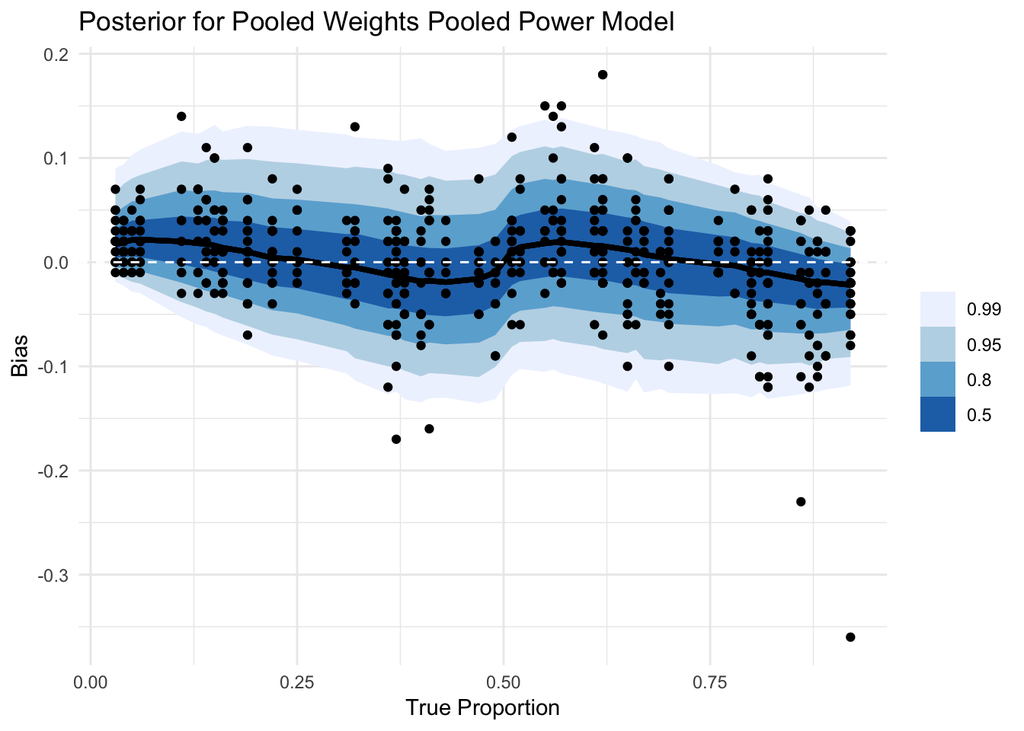

```r
PWPP_predicted_data <- spread_draws(PWPP_fit, response_pred[i]) %>%
  summarise_all(list)

PWPP_combined_data <- unnest(bind_cols(aaa_study_pie, PWPP_predicted_data))

PWPP_combined_data %>%
    ggplot(aes(x = correct_ans/100)) +
      stat_lineribbon(aes(y = (response_pred - correct_ans/100)), .width = c(.99, .95, .8, .5)) +
      scale_fill_brewer() +
      geom_point(aes (y = (flipped_ans/100 - correct_ans/100)), data = aaa_study_pie) +
      geom_hline(aes(yintercept=0), colour="white", linetype="dashed") +
  ggtitle("Posterior for Pooled Weights Pooled Power Model") +
  labs(x = "True Proportion", y="Bias") +
  theme_minimal()
```

#### QQ Plot

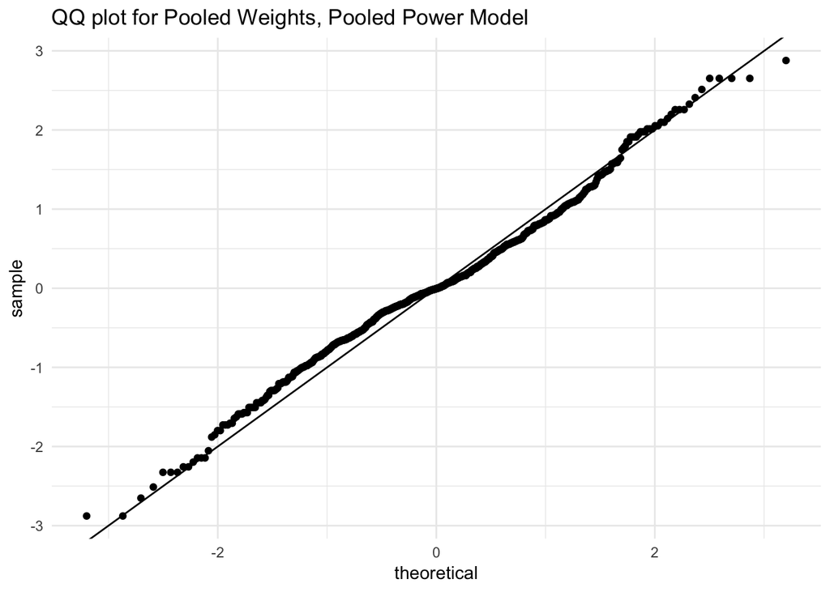

```r
PWPP_combined_data%>%
  group_by(i) %>%
    summarise(
      p_residual = mean(response_pred < flipped_ans/100),
      z_residual = qnorm(p_residual)
    ) %>%
    ggplot(aes(sample = z_residual)) +
    geom_qq() +
    geom_abline()+
    ggtitle("QQ plot for Pooled Weights, Pooled Power Model") + theme_minimal()
```

###Pooled Weights, Individual Power Model

#### Posterior Plot

```r
aaa_pie_data = list(n = length(aaa_study_pie$participant_ID), correct_ans = aaa_study_pie$correct_ans/100, response = aaa_study_pie$flipped_ans/100, segments = c(1,2,4), number_segments = 3, participant = aaa_study_pie$participant_ID, k = max(aaa_study_pie$participant_ID))

PWIP_fit <- stan(file ='models/pooled_wts_indv_power.stan' , data = aaa_pie_data, iter = 1000, chains = 1, verbose=TRUE)
```

```
##
## TRANSLATING MODEL 'pooled_wts_indv_power' FROM Stan CODE TO C++ CODE NOW.
## successful in parsing the Stan model 'pooled_wts_indv_power'.
```

```
## hash mismatch so recompiling; make sure Stan code ends with a blank line
```

[output not shown]

[output cut: 1168 more lines]

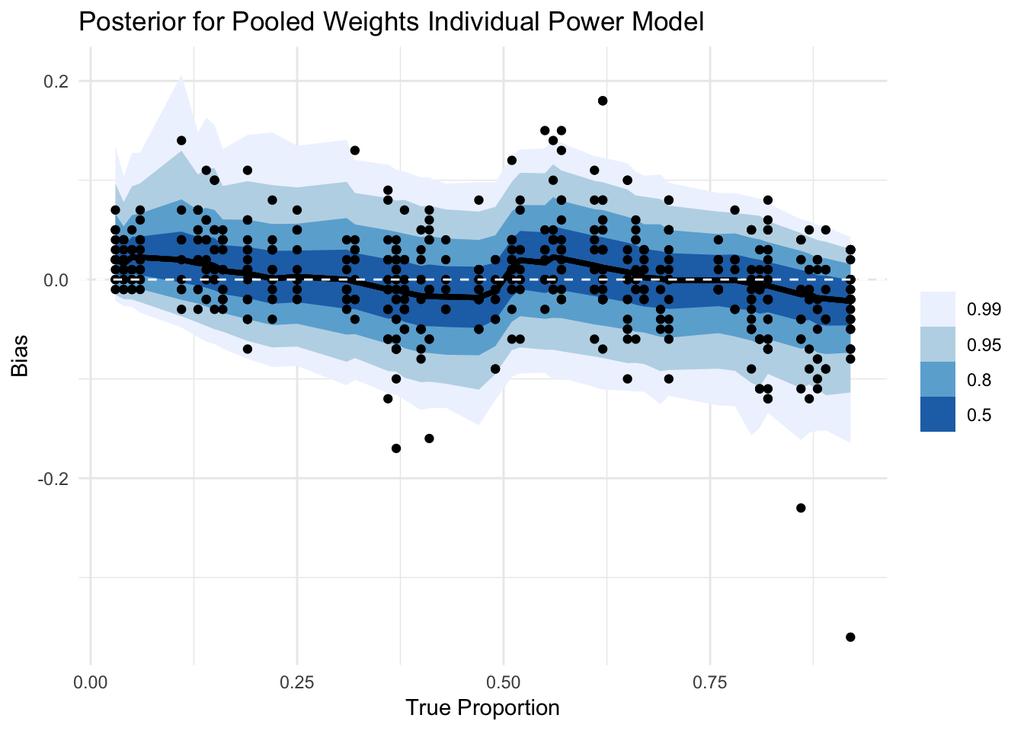

```r
PWIP_predicted_data <- spread_draws(PWIP_fit, response_pred[i]) %>%
  summarise_all(list)

PWIP_combined_data <- unnest(bind_cols(aaa_study_pie, PWIP_predicted_data))


PWIP_combined_data %>%
    ggplot(aes(x = correct_ans/100)) +
      stat_lineribbon(aes(y = (response_pred - correct_ans/100)), .width = c(.99, .95, .8, .5)) +
      scale_fill_brewer() +
      geom_point(aes (y = (flipped_ans/100 - correct_ans/100)), data = aaa_study_pie) +
  ggtitle("Posterior for Pooled Weights Individual Power Model") +
  geom_hline(aes(yintercept=0), colour="white", linetype="dashed") +
  labs(x = "True Proportion", y="Bias") +
  theme_minimal()
```

#### QQ Plot

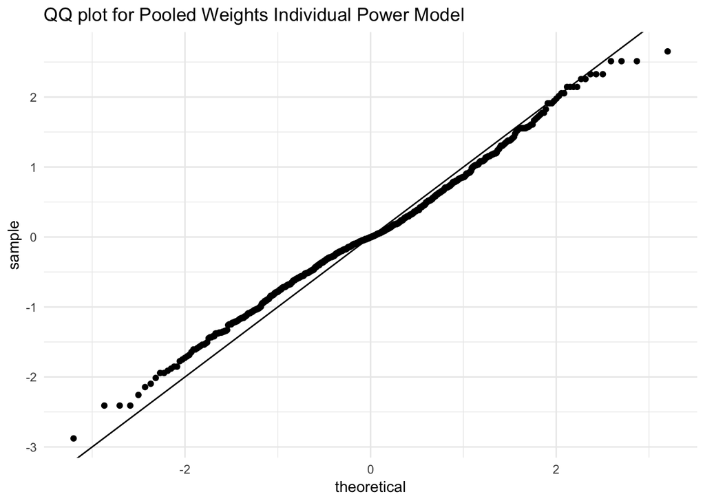

```r
PWIP_combined_data%>%
  group_by(i) %>%
    summarise(
      p_residual = mean(response_pred < flipped_ans/100),
      z_residual = qnorm(p_residual)
    ) %>%
    ggplot(aes(sample = z_residual)) +
    geom_qq() +
    geom_abline()+
    ggtitle("QQ plot for Pooled Weights Individual Power Model")
```

### Individual Weights, Pooled Power Model

#### Posterior Plot

```r
aaa_pie_data = list(n = length(aaa_study_pie$participant_ID), correct_ans = aaa_study_pie$correct_ans/100, response = aaa_study_pie$flipped_ans/100, segments = c(1,2,4), number_segments = 3, participant = aaa_study_pie$participant_ID, k = max(aaa_study_pie$participant_ID))

IWPP_fit <- stan(file ='models/indv_wts_pooled_power_model.stan' , data = aaa_pie_data, iter = 1000, chains = 1, verbose=TRUE, control = list(adapt_delta = 0.99, max_treedepth = 15))
```

```
##
## TRANSLATING MODEL 'indv_wts_pooled_power_model' FROM Stan CODE TO C++ CODE NOW.
## successful in parsing the Stan model 'indv_wts_pooled_power_model'.
```

```
## hash mismatch so recompiling; make sure Stan code ends with a blank line
```

[output not shown]

[output cut: 1351 more lines]

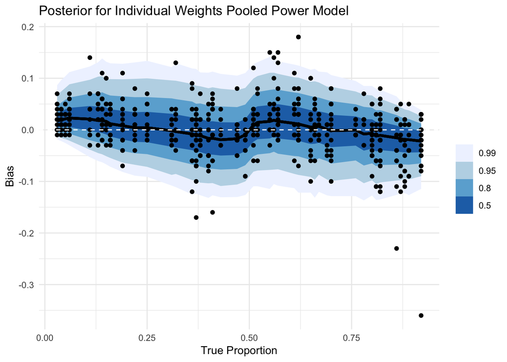

```r
IWPP_predicted_data <- spread_draws(IWPP_fit, response_pred[i]) %>%
  summarise_all(list)

IWPP_combined_data <- unnest(bind_cols(aaa_study_pie, IWPP_predicted_data))


IWPP_combined_data %>%
    ggplot(aes(x = correct_ans/100)) +
      stat_lineribbon(aes(y = (response_pred - correct_ans/100)), .width = c(.99, .95, .8, .5)) +
      scale_fill_brewer() +
      geom_point(aes (y = (flipped_ans/100 - correct_ans/100)), data = aaa_study_pie) +
  geom_hline(aes(yintercept=0), colour="white", linetype="dashed") +
  ggtitle("Posterior for Individual Weights Pooled Power Model") +
  labs(x = "True Proportion", y="Bias") +
  theme_minimal()
```

#### QQ Plot

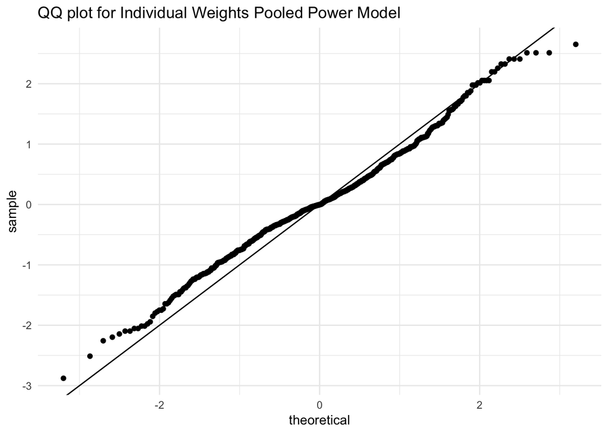

```r
IWPP_combined_data%>%
  group_by(i) %>%
    summarise(
      p_residual = mean(response_pred < flipped_ans/100),
      z_residual = qnorm(p_residual)
    ) %>%
    ggplot(aes(sample = z_residual)) +
    geom_qq() +
    geom_abline()+
    ggtitle("QQ plot for Individual Weights Pooled Power Model") + theme_minimal()
```

### Individual Weights, Individual Power Model

#### Posterior Plot

```r
aaa_pie_data = list(n = length(aaa_study_pie$participant_ID), correct_ans = aaa_study_pie$correct_ans/100, response = aaa_study_pie$flipped_ans/100, segments = c(1,2,4), number_segments = 3, participant = aaa_study_pie$participant_ID, k = max(aaa_study_pie$participant_ID))

IWIP_fit <- stan(file ='models/indv_wts_and_power_model.stan' , data = aaa_pie_data, iter = 1000, chains = 1, verbose=TRUE)
```

```
##
## TRANSLATING MODEL 'indv_wts_and_power_model' FROM Stan CODE TO C++ CODE NOW.
## successful in parsing the Stan model 'indv_wts_and_power_model'.
```

```
## hash mismatch so recompiling; make sure Stan code ends with a blank line
```

[output not shown]

[output cut: 1378 more lines]

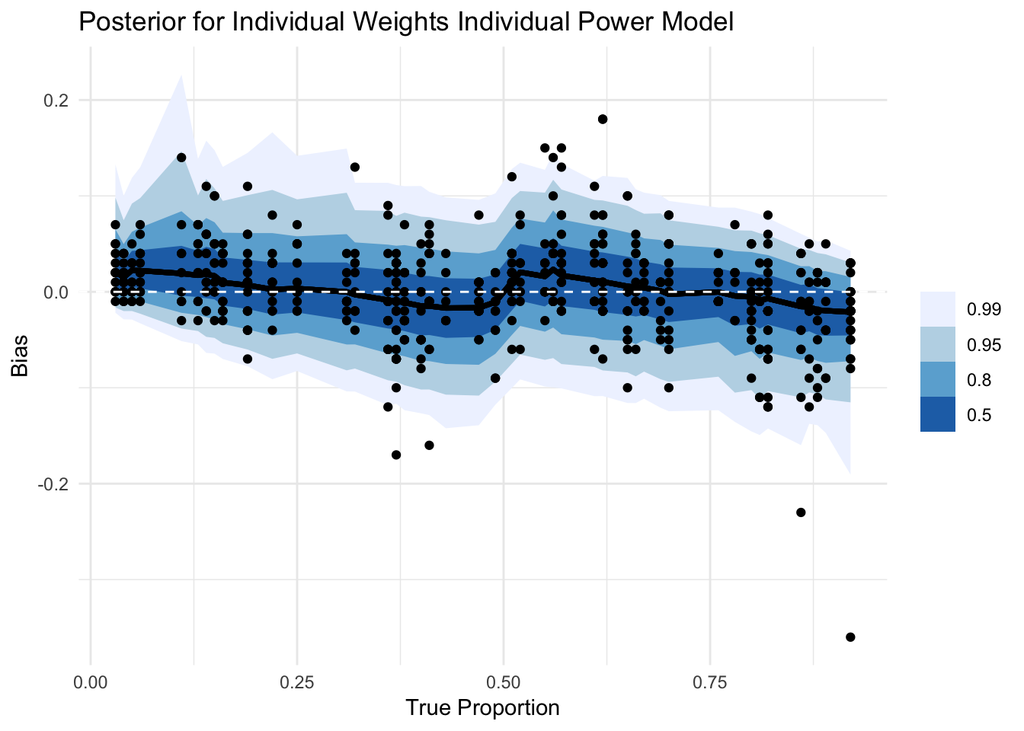

```r
IWIP_predicted_data <- spread_draws(IWIP_fit, response_pred[i]) %>%
  summarise_all(list)

IWIP_combined_data <- unnest(bind_cols(aaa_study_pie, IWIP_predicted_data))

IWIP_combined_data %>%
    ggplot(aes(x = correct_ans/100)) +
      stat_lineribbon(aes(y = (response_pred - correct_ans/100)), .width = c(.99, .95, .8, .5)) +
      scale_fill_brewer() +
      geom_point(aes (y = (flipped_ans/100 - correct_ans/100)), data = aaa_study_pie) +
      geom_hline(aes(yintercept=0), colour="white", linetype="dashed") +
  ggtitle("Posterior for Individual Weights Individual Power Model") +
  labs(x = "True Proportion", y="Bias") +
  theme_minimal()
```

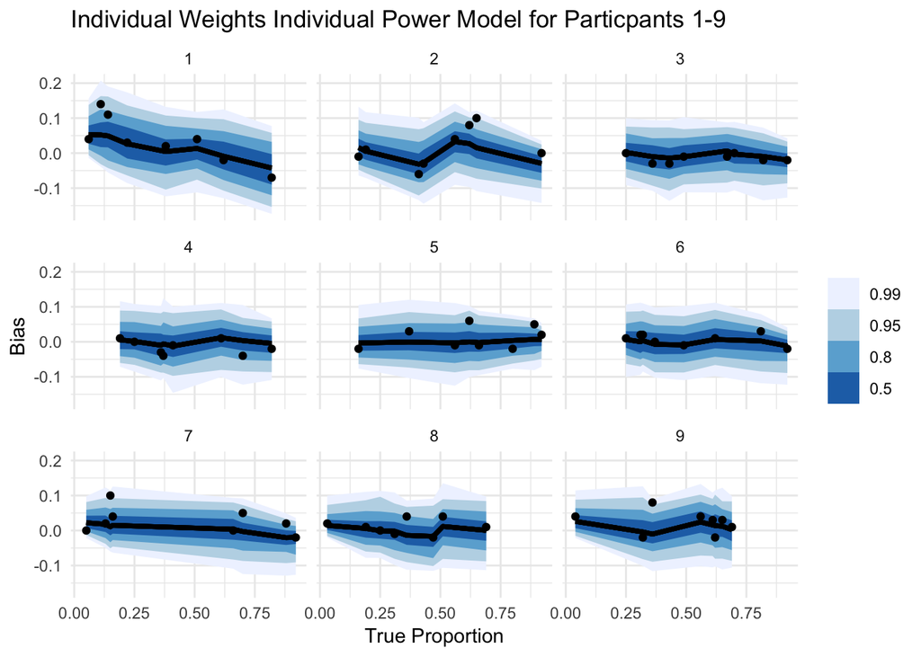

```r
IWIP_combined_data %>%
  filter(participant_ID <= 9) %>%
    ggplot(aes(x = correct_ans/100)) +
      stat_lineribbon(aes(y = (response_pred - correct_ans/100)), .width = c(.99, .95, .8, .5)) +
      scale_fill_brewer() +
      facet_wrap( ~ participant_ID, nrow = 3 ) +
      geom_point(aes (y = (flipped_ans/100 - correct_ans/100)), data= subset(aaa_study_pie, participant_ID <= 9 )) +
  ggtitle("Individual Weights Individual Power Model for Particpants 1-9") +
  labs(x = "True Proportion", y="Bias") +
  theme_minimal()
```

#### QQ Plot

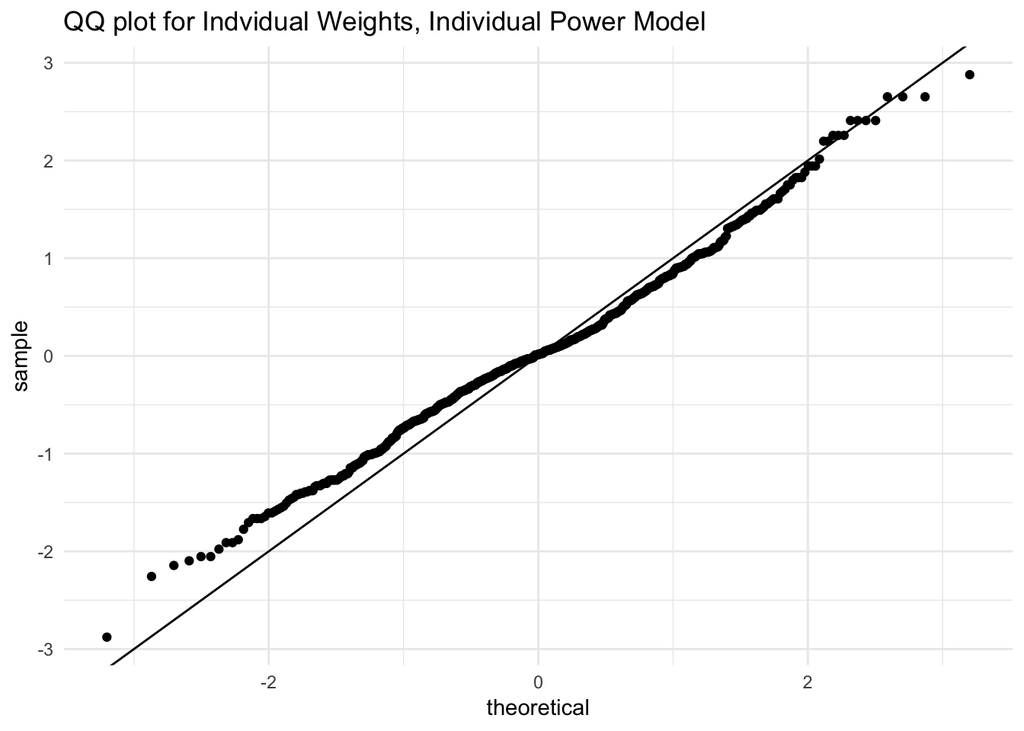

```r
IWIP_combined_data%>%
  group_by(i) %>%
    summarise(
      p_residual = mean(response_pred < flipped_ans/100),
      z_residual = qnorm(p_residual)
    ) %>%
    ggplot(aes(sample = z_residual)) +
    geom_qq() +
    geom_abline()+
    ggtitle("QQ plot for Indvidual Weights, Individual Power Model") + theme_minimal()
```